# blog post 7

Eunyeong Park

2022-12-02

For *blog post 7*, we address how we plan to the continuation of our exploratory data analysis. Our next blog (8) will address our tentative thesis, visualizations, and tables.

## Feature Extraction

We are using the correlation matrix to find high positive or negative correlations between the population and our dependent variables, which indicates potential predictors of the high international student population. From this, we expected to get more of a sense of which variablesa are highly related to the population of international students.

```
## [1] international_students_opendoors enrollment_top120enrollment
## [3] city_population                  international_students_qs
## [5] international_students_natlib    city_population_density
## 22 Levels: score_qs pub_arwu n_s_arwu alumni_arwu hi_ci_arwu ... faculty_count_qs
## [1] city_population_density faculty_count_qs
## 22 Levels: score_qs pub_arwu n_s_arwu alumni_arwu hi_ci_arwu ... faculty_count_qs
```

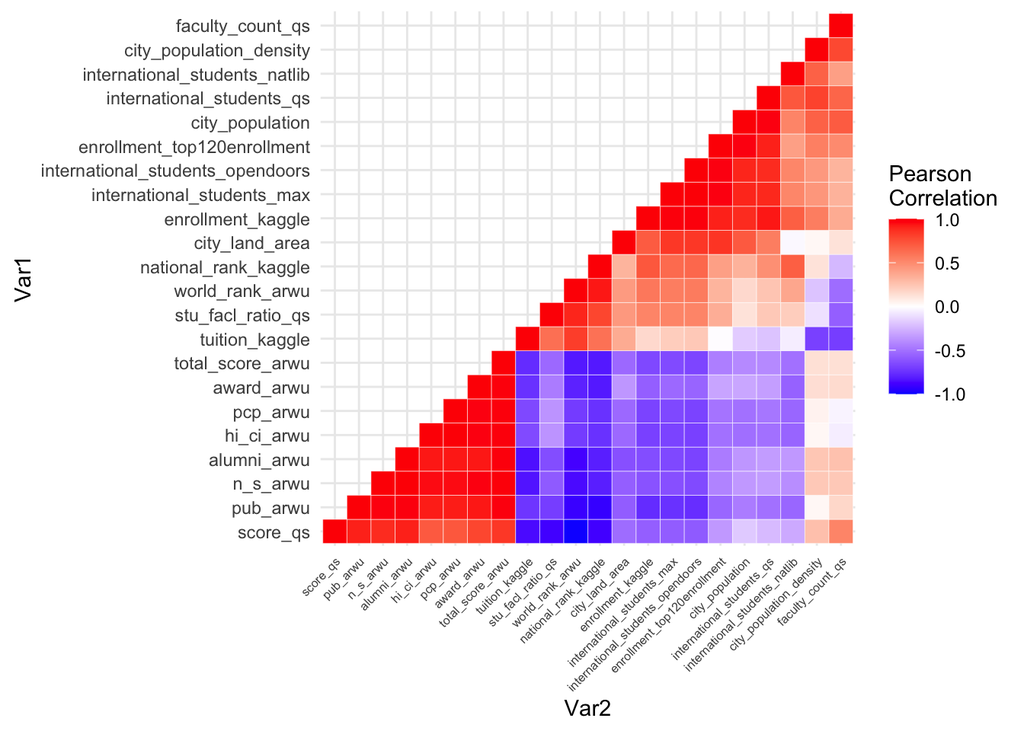

Next, we select numerical features that have a large correlation coefficient (absolute value being greater than 0.4) in relation to **international_students_natlib(percentage of international students)** and **international_students_max(The maximun of international_students_qs and international_students_opendoors)**.

For **international_students_natlib**, we have the relevant numerical features: city_population_density, faculty_count_qs

For **international_students_max**, we have the relevant numerical features: international_students_opendoors, enrollment_top120enrollment,  
city_population, international_students_qs, international_students_natlib,  
city_population_density

From this finding we made few graphs:

### City Population Density and International Student Percentage

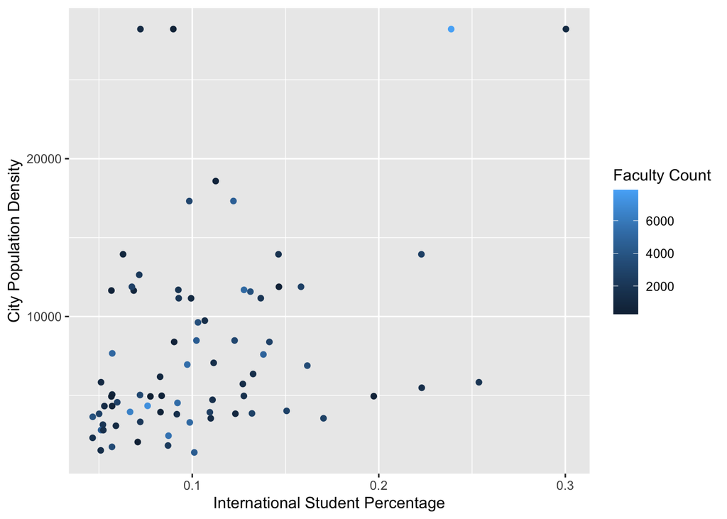

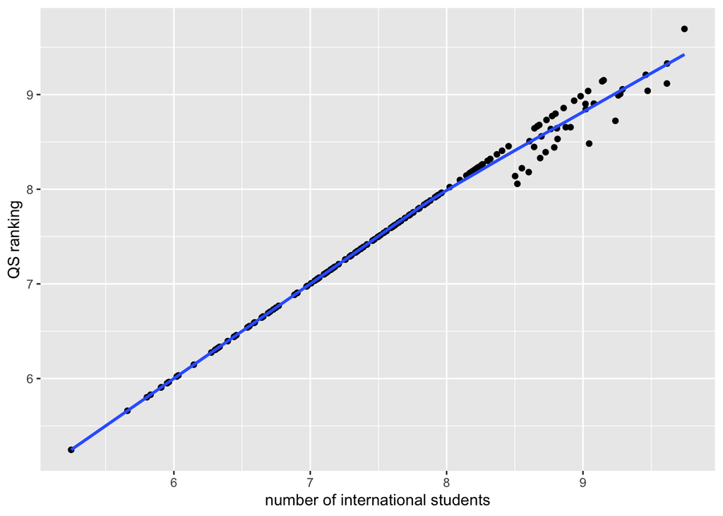

### Estimate States’ University International Student Population by mean

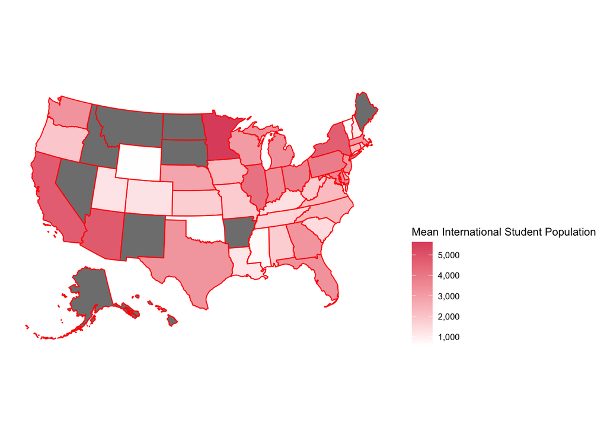

*Our next step* would be extracting the relevant non-numerical features. An idea for this is using scatter plots between variables or converting the variables to numerical ones. For example, we could convert campus size factors (S, M, L, XL) to integers.

## Modeling

Using the pruned features, for a baseline, we will create linear regression(lm) or generalized linear models(glm).

Then, we are interested in upscaling the performance using methods such as step-wise regression and lasso regression.

Note: We have created lm and glms before, but only naively selected the independent variables.

## Evaluation

Since we are solving a regression problem, we will be using Root Mean Square Error as an evaluation method. Additionally, we plan to use information criterion methods (AIC, BIC) to also measure model performance.

## Acknowledgments

“GGPLOT2 : Quick Correlation Matrix Heatmap - R Software and Data Visualization.” STHDA, http://www.sthda.com/english/wiki/ggplot2-quick-correlation-matrix-heatmap-r-software-and-data-visualization.